# Analyse georeferenced

Bastien Grasset

11 août, 2022

# 1 The data

The analyzed data are : - */home/grasset/Documents/Tunaatlas_level1/jobs/20220811150249/entities/global_catch_1deg_1m_ps_bb_Bastien_level0/Markdown/rawdata for the initial data*

The filters used are:

- on species:
- on gears:
- on rfmos:
- on fleets:
- on initial dates:
- on final dates:
- on geographical categories:
- on catch types:

## 1.1 Catch evolutions

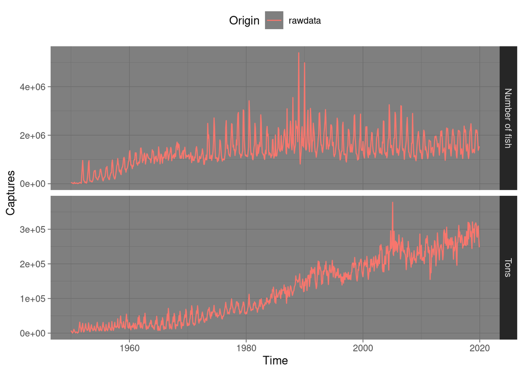

## 1.2 Evolution of the cumulative catches

[figure not shown]

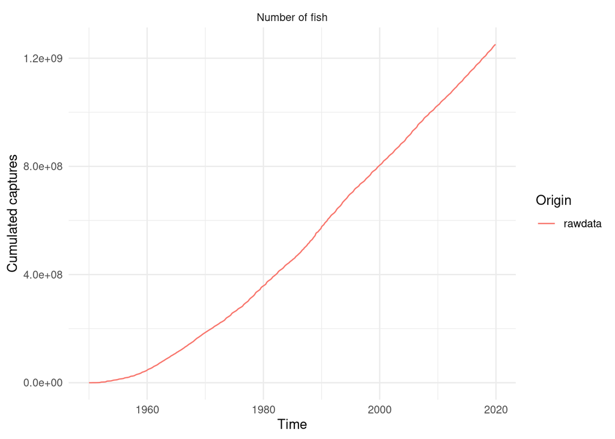

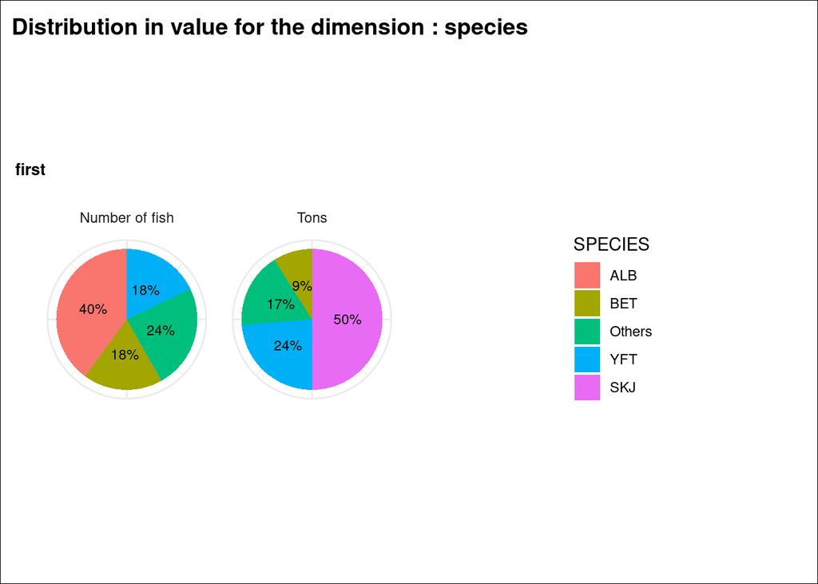

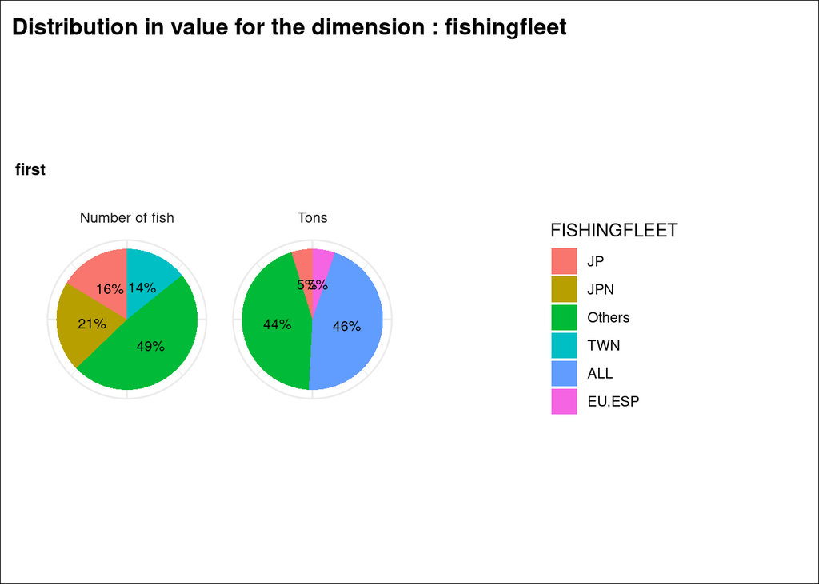

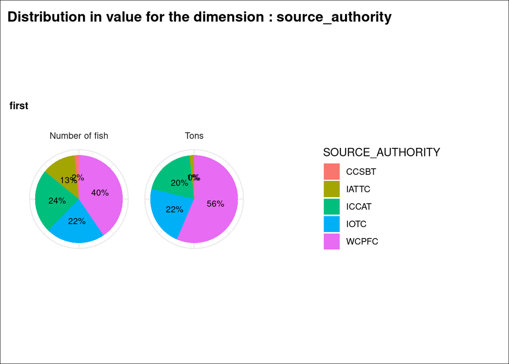

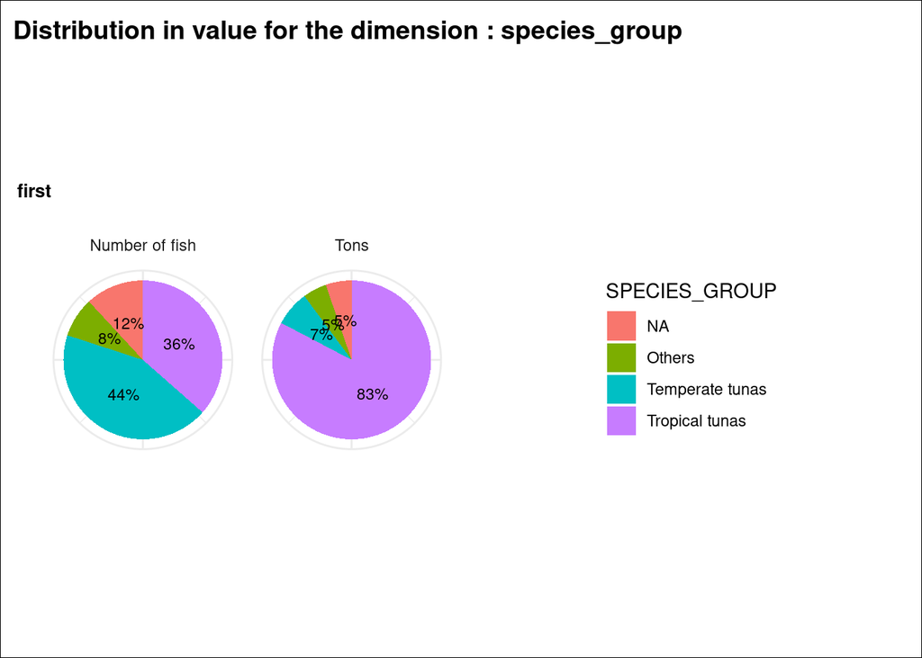

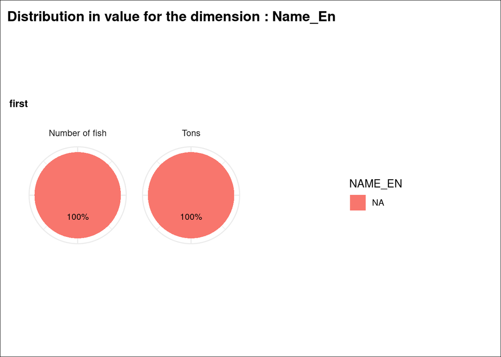

# 2 How much data is mislocated on continents ?

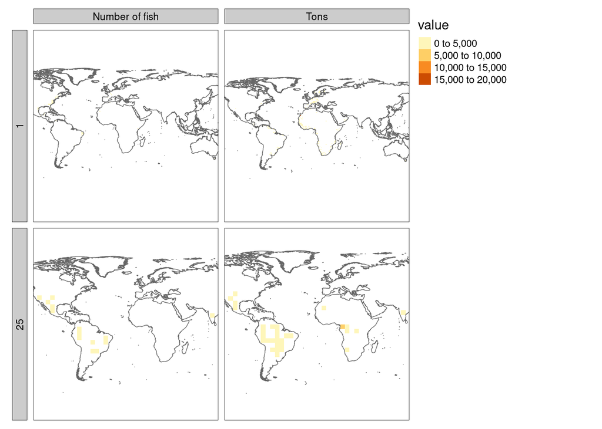

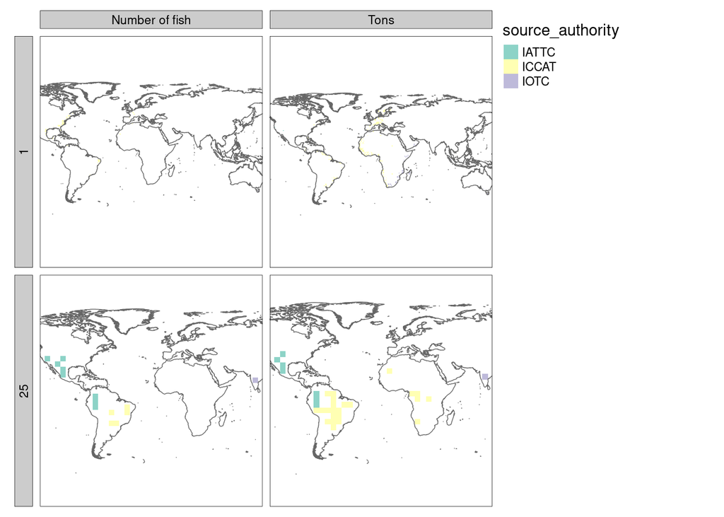

# 3 Distribution of mislocated data

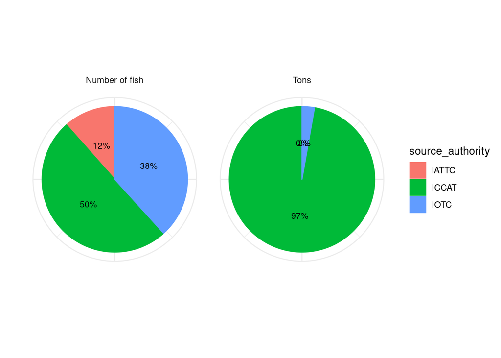

*This markdown is aimed to study the repartition of each unity for a specific dataset, in this case is /home/grasset/Documents/Tunaatlas_level1/jobs/20220811150249/entities/global_catch_1deg_1m_ps_bb_Bastien_level0/Markdown/rawdata.*

Removing the data placed on the continents, the losses at the end of level 0 amount to 0.001468 % in number and 0.0424443 % in tons.

We are now interested in the mislocated data

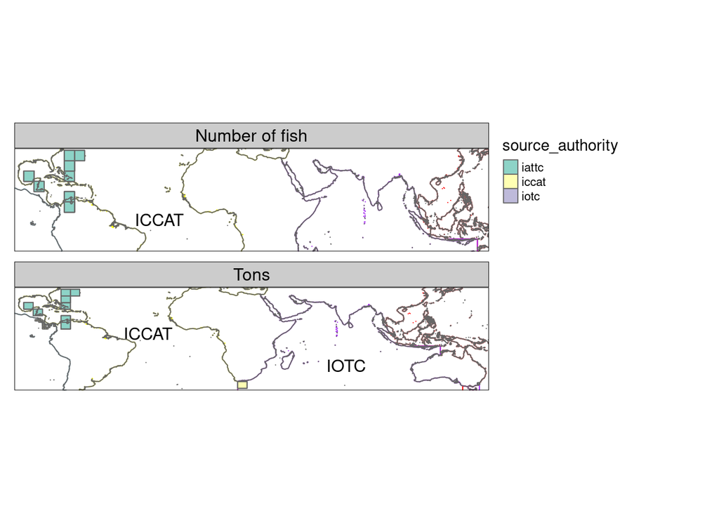

Removing data placed on continents, as well as data from an rfmo in an area outside their jurisdiction, the losses at the end of level 0 amount to 1.6031767 % in number and 0.183013 % in tons.

# 4 Absurd conversion factors

We analyse here the data with conversion factors “absurd”, meaning being superior to the maximum catch for the fish of the same species.

We compare the data of this conversion factors absurd, with the total data to see any pattern.

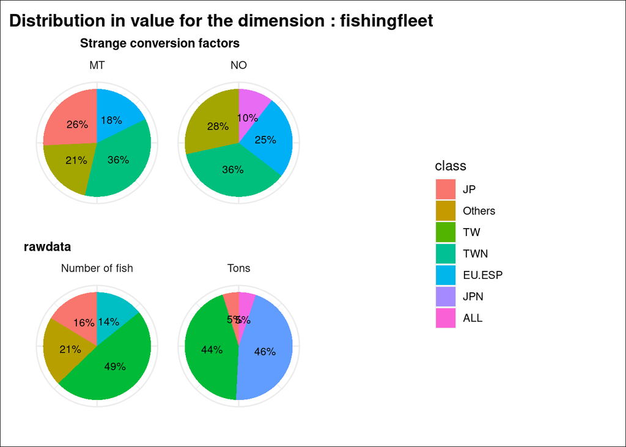

# 5 Mislocated data

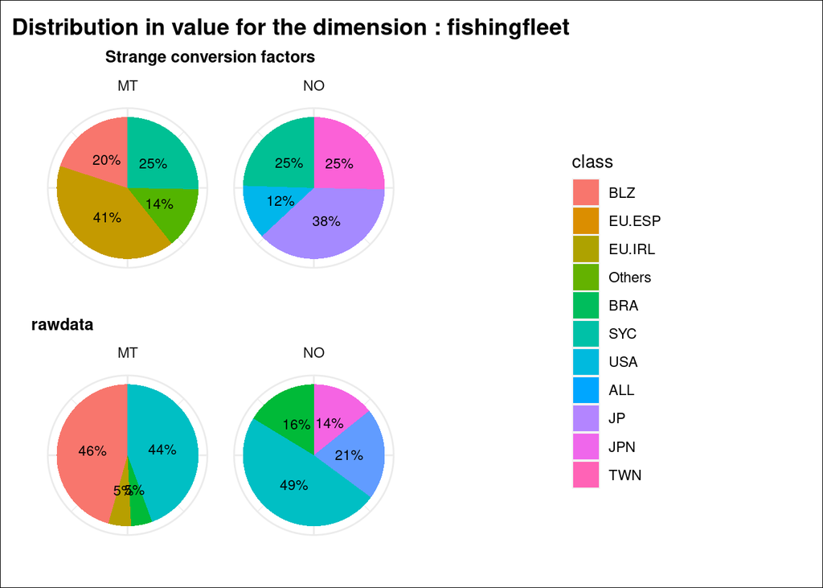

[figure not shown]

[figure not shown]

[figure not shown]